# The Unique Housing Patterns of the Asian Population in the United Kingdom

## 3.3 Income Distribution Across Ethnic Groups, Grouped by Marital Status

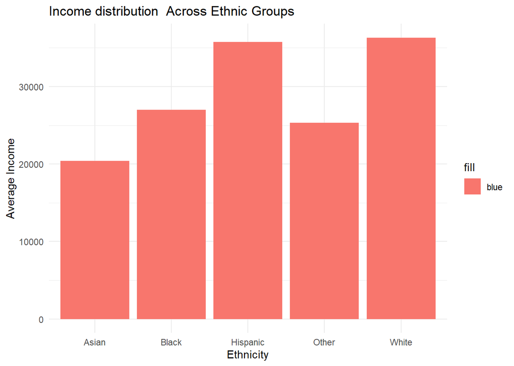

(a) Average Income by Ethnicity

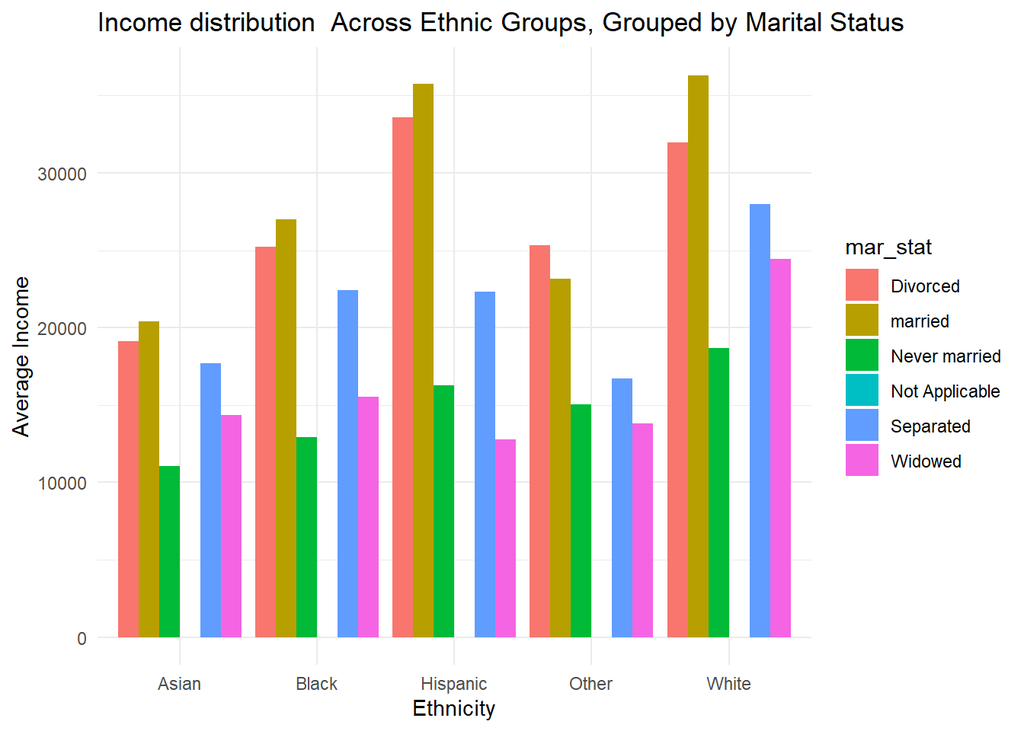

(b) Average Income by Ethnicity grouped by marital status

Figure 3: Income Distribution Across Ethnic Groups Grouped by Marital Status

```r
pop <- population |>
  group_by(eth, mar_stat) |>
  summarise(avg_income = mean(inc))
ggplot(pop, aes(x = eth, y = avg_income, fill = 'blue'))+
  geom_bar(stat = 'identity', position = 'dodge')+
  labs(title = "Income distribution  Across Ethnic Groups",
       x = "Ethnicity",y = "Average Income")+theme_minimal()

ggplot(pop, aes(x = eth, y = avg_income, fill = mar_stat))+
  geom_bar(stat = 'identity', position = 'dodge')+
  labs(title = "Income distribution  Across Ethnic Groups, Grouped by Marital Status",
       x = "Ethnicity", y = "Average Income", color = "Marital Status") +  theme_minimal()
```

## 3.4 Distribution of Age Groups Across Ethnic Groups, Grouped by Gender

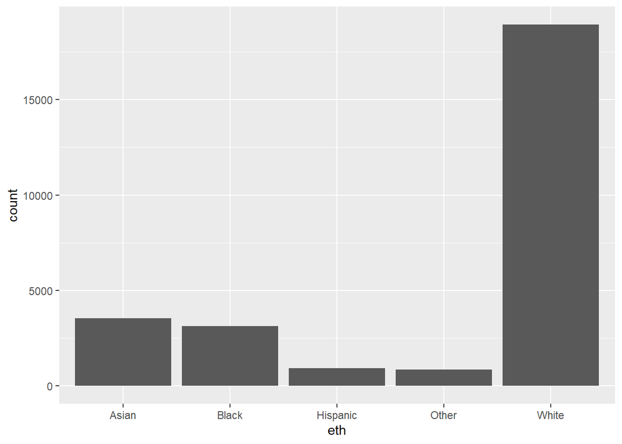

(a) Population distribution by Ethicity

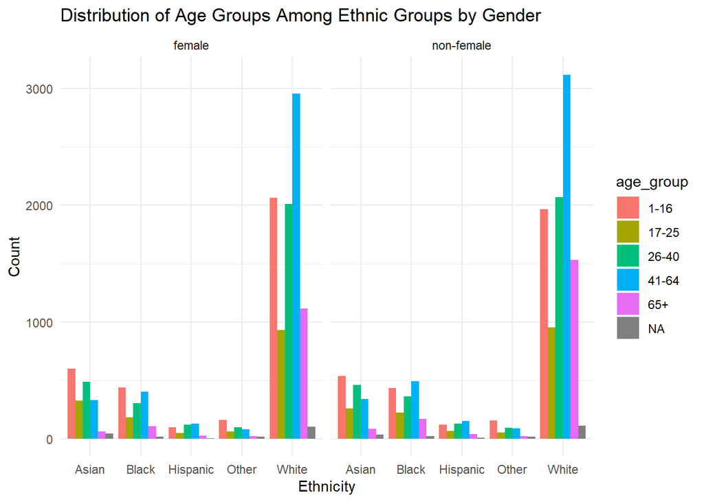

(b) Age Groups Among Ethnicity Grouped by Gender

Figure 4: Distribution of Age Groups Among Ethnicity Grouped by Gender

```r
ggplot(population, aes(x = eth))+ geom_bar()

ggplot(population, aes(x = eth)) +
  geom_bar(aes(fill = age_group), position = 'dodge') +
  facet_wrap(~ factor(female, labels = c('female', 'non-female')))+
  labs(title = 'Distribution of Age Groups Among Ethnic Groups by Gender', x = 'Ethnicity', y = 'Count') +
  theme_minimal()
```

From Figure 4 (a), the investigation shows that Whites have the highest percentage of the total population. This is not surprising as the census was conducted in the UK where the population are Whites. It is however interesting to note that next to the Whites, the Asians have the highest number of population. This is followed by the Blacks, and there are only very few Hispanics and other ethnic groups in the United Kingdom. Thus, it is safe to say that Asians constitute the highest number of immigrants in the United Kingdom. The column ‘age’ was categorised into distinct groups to provide a more nuanced understanding of the data based on age ranges. This stratification aims to capture variations in likely income levels and educational qualifications associated with these age groups.From Figure 4 (b), the Asians have their highest population between the age 1-16 for both male and females. All ethnic groups except Whites have the smallest percentage of their population within the age group 65 and above. Whites, Blacks and Hispanics have more people within the ages of 41-64

```r
population$child <- ifelse(population$age < 16, 1, 0)
child_counts <- population |>
  group_by(id,  eth) |>
  summarize(NumChildren = sum(child))
# Aggregate data by household and ethnicity, calculating the count of children in each group
child_counts <- aggregate(child ~ id + eth, data = population, sum)
# Find the ethnic group with the highest number of children in each household
max_child_ethnicity <- child_counts[which.max(child_counts$child),'child']
```